# Spatial LR Correlation via Bivariate Moran’s I (LIANA+)

For each LR pair: does ligand expression in a cell predict receptor expression in its neighbours (bivariate Moran’s I)? Uses expression and coordinates only, no cell-type labels.

Input: the export from `08` (`output/08_STARmapPLUS_CCC_GenePanelCheck/starmap_hpc_export/`). One section only (spatial graphs are per section); `10` runs all 4 sections.

## 1 Imports

```python
import numpy as np
import pandas as pd
import scipy.io as sio
import anndata as ad
import liana as li
import matplotlib.pyplot as plt
```

## 2 Build the AnnData object

```python
import os
export_dir = "output/08_STARmapPLUS_CCC_GenePanelCheck/starmap_hpc_export"   # written by 08_STARmapPLUS_CCC_GenePanelCheck.qmd
out_dir    = "output/09_STARmapPLUS_BivariateMoransI"
os.makedirs(out_dir, exist_ok=True)

expr = sio.mmread(f"{export_dir}/expr_norm.mtx").tocsr().T  # genes x cells -> cells x genes for AnnData

genes = pd.read_csv(f"{export_dir}/genes.txt", header=None)[0].astype(str).tolist()
cells = pd.read_csv(f"{export_dir}/cells.txt", header=None)[0].astype(str).tolist()

coords = pd.read_csv(f"{export_dir}/coordinates.csv").set_index("cell_id").loc[cells]
meta   = pd.read_csv(f"{export_dir}/metadata.csv").set_index("cell_id").loc[cells]

print(f"Loaded {len(cells)} cells total, unfiltered (all samples/replicates/ages combined).")
```

```
Loaded 16278 cells total, unfiltered (all samples/replicates/ages combined).
```

## 3 Choose the section

Prints the available sample/age columns; `selection_filter` (next cell) selects one section, default `13months_replicate_1`. `None` would pool all sections into one graph.

```python
# print candidate sample/replicate/age columns and their values
candidate_keywords = ["sample", "replic", "age", "time", "slide", "batch", "group", "condition"]
candidate_cols = [c for c in meta.columns if any(k in c.lower() for k in candidate_keywords)]

if candidate_cols:
    print("Metadata columns that look like sample/replicate/age/timepoint identifiers:")
    for c in candidate_cols:
        print(f"\n'{c}' -- {meta[c].nunique(dropna=False)} unique value(s):")
        print(meta[c].value_counts(dropna=False))
else:
    print("No obvious sample/replicate/age/timepoint column found by name. Full column list:")
    print(meta.columns.tolist())
```

```
Metadata columns that look like sample/replicate/age/timepoint identifiers:

'biosample_id' -- 4 unique value(s):
biosample_id
ADmouse_11351_brain    4602
ADmouse_9707_brain     4075
ADmouse_9498_brain     3901
ADmouse_9735_brain     3700
Name: count, dtype: int64

'batch' -- 3 unique value(s):
batch
batch_4    8677
batch_2    3901
batch_1    3700
Name: count, dtype: int64

'time' -- 2 unique value(s):
time
13months    8503
8months     7775
Name: count, dtype: int64

'group' -- 1 unique value(s):
group
control    16278
Name: count, dtype: int64

'replicate' -- 2 unique value(s):
replicate
replicate_2    8677
replicate_1    7601
Name: count, dtype: int64
```

```python
# Select section to use
# None would pool all sections into one spatial graph
selection_filter = {"section_id": "13months_replicate_1"}

if selection_filter:
    mask = pd.Series(True, index=meta.index)
    for col, keep_vals in selection_filter.items():
        if col not in meta.columns:
            raise KeyError(f"'{col}' not in metadata columns: {meta.columns.tolist()}")
        keep_vals = keep_vals if isinstance(keep_vals, (list, tuple, set)) else [keep_vals]
        mask &= meta[col].isin(keep_vals)

    n_before = len(cells)
    mask_arr = mask.to_numpy()
    cells  = [c for c, keep in zip(cells, mask_arr) if keep]
    meta   = meta.loc[mask]
    coords = coords.loc[mask]
    expr   = expr.tocsr()[mask_arr]

    print(f"Filtered to {len(cells)}/{n_before} cells matching {selection_filter}.")
    if len(cells) == 0:
        raise RuntimeError("Filter matched 0 cells -- check the values against the printout in the cell above.")
else:
    print(f"No filter applied -- keeping all {len(cells)} cells (all samples/replicates/ages combined).")
```

```
Filtered to 3901/16278 cells matching {'section_id': '13months_replicate_1'}.
```

```python
adata = ad.AnnData(X=expr, obs=meta, var=pd.DataFrame(index=genes))
adata.obsm["spatial"] = coords[["spatial_1", "spatial_2"]].to_numpy()

adata
```

```
AnnData object with n_obs × n_vars = 3901 × 2766
    obs: 'orig.ident', 'nCount_RNA', 'nFeature_RNA', 'NAME', 'biosample_id', 'donor_id', 'species', 'species__ontology_label', 'sex', 'disease', 'disease__ontology_label', 'organ', 'organ__ontology_label', 'library_preparation_protocol', 'library_preparation_protocol__ontology_label', 'orig_index', …
    obsm: 'spatial'
```

## 4 Choose the neighbourhood bandwidth

Gaussian kernel with a distance bandwidth (cells are not on a grid like Visium spots). The plot draws circles of the chosen radius around example cells and reports how many cells fall inside.

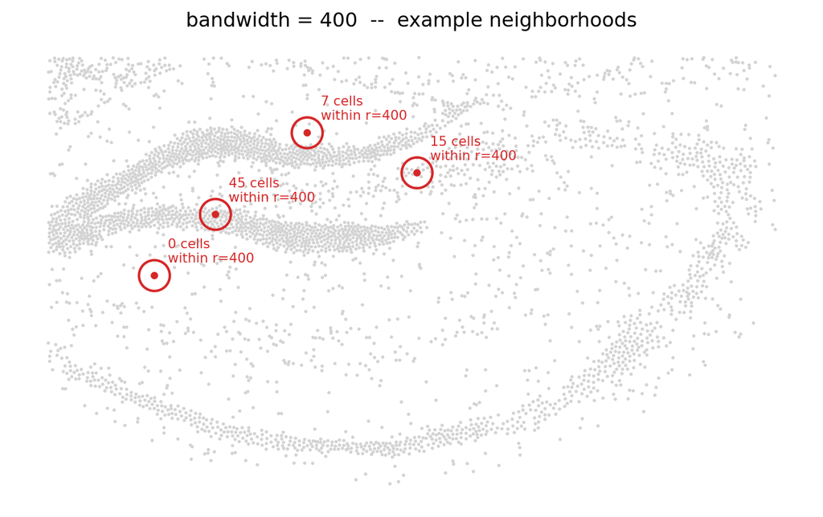

```python
from matplotlib.patches import Circle

def plot_bandwidth_scale(bandwidth, n_examples=4, seed=0):
    """Visualize what a candidate Gaussian-kernel bandwidth (same spatial units as
    adata.obsm['spatial']) looks like against the real cell density: draws a circle of
    that radius around a few example cells and reports how many other cells actually
    fall inside each one -- a rough 'effective neighbor count'."""
    coords = adata.obsm["spatial"]
    rng = np.random.default_rng(seed)
    example_idx = rng.choice(adata.n_obs, size=n_examples, replace=False)

    fig, ax = plt.subplots(figsize=(7, 7))
    ax.scatter(coords[:, 0], coords[:, 1], color="lightgrey", s=4, edgecolors="none")

    for idx in example_idx:
        cx, cy = coords[idx]
        dist = np.sqrt((coords[:, 0] - cx) ** 2 + (coords[:, 1] - cy) ** 2)
        n_within = int((dist <= bandwidth).sum()) - 1  # exclude the point itself
        ax.add_patch(Circle((cx, cy), bandwidth, fill=False, edgecolor="#d62728", linewidth=1.5))
        ax.scatter([cx], [cy], color="#d62728", s=20, zorder=5, edgecolors="none")
        ax.annotate(f"{n_within} cells\nwithin r={bandwidth}", (cx, cy), textcoords="offset points",
                    xytext=(8, 8), fontsize=8, color="#d62728")

    ax.set_aspect("equal")
    ax.invert_yaxis()
    ax.axis("off")
    ax.set_title(f"bandwidth = {bandwidth}  --  example neighborhoods")
    plt.tight_layout()
    plt.show()

plot_bandwidth_scale(bandwidth=400)
```

## 5 Build the spatial neighbours graph

`set_diag=True` includes each cell as its own neighbour (liana’s default).

```python
li.ut.spatial_neighbors(adata, bandwidth=400, kernel="gaussian", set_diag=True)

print("obsp keys:", list(adata.obsp.keys()))
print("uns keys: ", list(adata.uns.keys()))
for k in adata.uns.keys():
    if "spatial" in k.lower() or "neighbor" in k.lower():
        print(f"uns['{k}']:", adata.uns[k])
```

```
obsp keys: ['spatial_connectivities']
uns keys:  []
```

## 6 Bivariate Moran’s I for the LR pairs

All panel-covered LR pairs from `08`. With `local_name` set, the result is an AnnData: `.var` = global score and p-value per pair, `.X` = local score per cell (cells x pairs).

```python
lr_pairs = pd.read_csv(f"{export_dir}/lr_pairs.csv")
interactions = list(zip(lr_pairs["ligand_complex"], lr_pairs["receptor_complex"]))

bivar_adata = li.mt.bivariate(
    adata,
    resource_name=None,
    interactions=interactions,
    global_name="morans",
    local_name="morans",
    connectivity_key="spatial_connectivities",
    n_perms=200,
    mask_negatives=False,   # whether to mask LowLow/NegativeNegative interactions
    add_categories=True,    # whether to add local categories to the results
    nz_prop=0,
    seed=1337,
    use_raw=False,
    verbose=False,
)

bivar_adata
```

```
AnnData object with n_obs × n_vars = 3901 × 13
    obs: 'orig.ident', 'nCount_RNA', 'nFeature_RNA', 'NAME', 'biosample_id', 'donor_id', 'species', 'species__ontology_label', 'sex', 'disease', 'disease__ontology_label', 'organ', 'organ__ontology_label', 'library_preparation_protocol', 'library_preparation_protocol__ontology_label', 'orig_index', …
    var: 'ligand', 'receptor', 'ligand_means', 'ligand_props', 'receptor_means', 'receptor_props', 'morans', 'morans_pvals', 'mean', 'std'
    obsm: 'spatial'
    layers: 'cats', 'pvals'
    obsp: 'spatial_connectivities'
```

## 7 Global results

```python
assert list(bivar_adata.obs_names) == list(adata.obs_names), (
    "bivar_adata's cell order doesn't match adata's -- reindex before using local scores spatially."
)

global_scores = bivar_adata.var.copy()
print("columns:", global_scores.columns.tolist())
print("shape:", global_scores.shape)
global_scores.head()
```

```
columns: ['ligand', 'receptor', 'ligand_means', 'ligand_props', 'receptor_means', 'receptor_props', 'morans', 'morans_pvals', 'mean', 'std']
shape: (13, 10)
```

| interaction | ligand | receptor | ligand_means | ligand_props | receptor_means | receptor_props | morans | morans_pvals | mean | std |
| --- | --- | --- | --- | --- | --- | --- | --- | --- | --- | --- |
| Calm1^Ptpra | Calm1 | Ptpra | 2.805595 | 0.645219 | 0.445960 | 0.117918 | 0.020601 | 0.00 | 0.041347 | 0.412887 |
| Sptan1^Ptpra | Sptan1 | Ptpra | 0.181966 | 0.049731 | 0.445960 | 0.117918 | 0.003778 | 0.06 | 0.007737 | 0.234477 |
| Adam10^Notch2 | Adam10 | Notch2 | 0.241387 | 0.062804 | 0.406531 | 0.101000 | 0.004773 | 0.02 | 0.009420 | 0.201157 |
| Cxcl12^Itgb1 | Cxcl12 | Itgb1 | 0.583121 | 0.142271 | 0.357992 | 0.091002 | -0.012002 | 0.00 | -0.024496 | 0.284016 |
| Ptn^Ptprs | Ptn | Ptprs | 0.124277 | 0.031787 | 1.248909 | 0.320431 | -0.004217 | 0.04 | -0.008272 | 0.230657 |

## 8 Local-score categories

Checks which extra layers (e.g. High-High / Low-Low categories) `bivariate()` returned.

```python
print("layers:", list(bivar_adata.layers.keys()))
print("obsm:  ", list(bivar_adata.obsm.keys()))
print("obsp:  ", list(bivar_adata.obsp.keys()))
print("uns:   ", list(bivar_adata.uns.keys()))
print("var columns (already seen above):", bivar_adata.var.columns.tolist())

# show the content of a categories layer, if present
for key in bivar_adata.layers:
    sample = np.asarray(bivar_adata.layers[key][:, 0]).reshape(-1)[:10]
    print(f"\nlayers['{key}'] sample (first pair, first 10 cells): {sample}")
```

```
layers: ['cats', 'pvals']
obsm:   ['spatial']
obsp:   ['spatial_connectivities']
uns:    []
var columns (already seen above): ['ligand', 'receptor', 'ligand_means', 'ligand_props', 'receptor_means', 'receptor_props', 'morans', 'morans_pvals', 'mean', 'std']

layers['cats'] sample (first pair, first 10 cells): [<3901x1 sparse matrix of type '<class 'numpy.int64'>'
    with 2980 stored elements in Compressed Sparse Row format>]

layers['pvals'] sample (first pair, first 10 cells): [<3901x1 sparse matrix of type '<class 'numpy.float64'>'
    with 3703 stored elements in Compressed Sparse Row format>]
```

## 9 Global Moran’s I, ranked

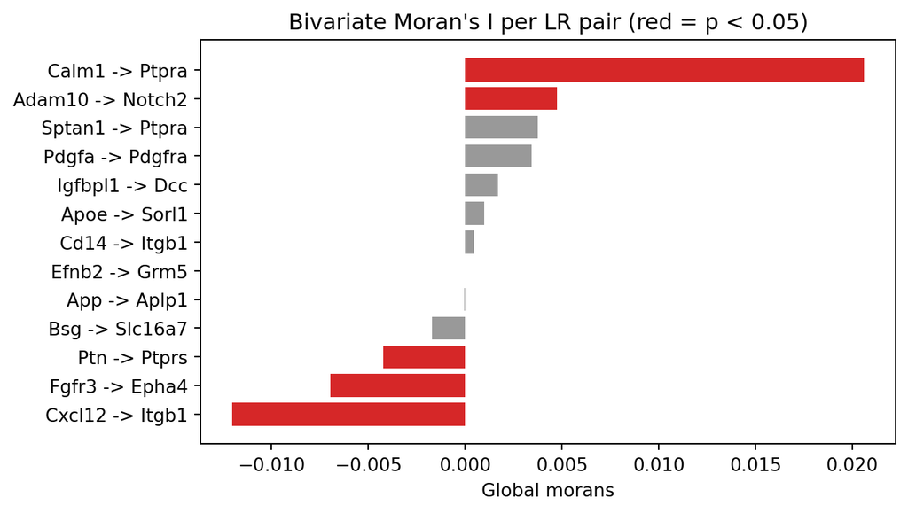

```python
score_col = next((c for c in global_scores.columns if "morans" in c.lower() and "pval" not in c.lower()), None)
pval_col  = next((c for c in global_scores.columns if "pval" in c.lower()), None)
if score_col is None:
    raise RuntimeError(f"Could not find a Moran's I score column. Columns present: {global_scores.columns.tolist()}")

pair_label = global_scores["ligand"].astype(str) + " -> " + global_scores["receptor"].astype(str)
plot_df = global_scores.assign(pair_label=pair_label).sort_values(score_col, ascending=False)
sig_mask = (plot_df[pval_col] < 0.05) if pval_col else pd.Series(False, index=plot_df.index)

fig, ax = plt.subplots(figsize=(7, max(4, 0.3 * len(plot_df))))
ax.barh(plot_df["pair_label"], plot_df[score_col], color=["#d62728" if s else "#999999" for s in sig_mask])
ax.invert_yaxis()
ax.set_xlabel(f"Global {score_col}")
ax.set_title("Bivariate Moran's I per LR pair" + (" (red = p < 0.05)" if pval_col else ""))
plt.tight_layout()
plt.show()
```

## 10 Ligand and receptor expression in space

Pairs with significant (p < 0.05) **positive** global Moran’s I. Complexes use the mean of their subunits.

```
2/13 pairs significant at p < 0.05 with positive global morans (3 significant-but-negative pair(s) excluded).
Plotting 3901 cells.
Calm1 -> Ptpra: 0/3901 cells (0.0%) have NaN local score
Adam10 -> Notch2: 0/3901 cells (0.0%) have NaN local score
```

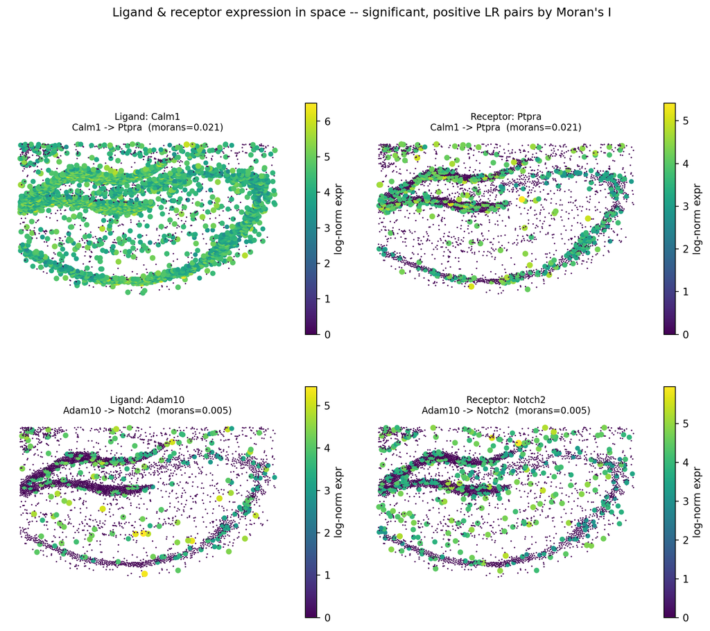

```python
def complex_expression(complex_str):
    """Mean log-normalized expression across a complex's subunit genes (genes joined by '_', if any)."""
    genes = [g for g in complex_str.split("_") if g in adata.var_names]
    if len(genes) == 0:
        return None
    vals = adata[:, genes].X
    vals = np.asarray(vals.todense()) if hasattr(vals, "todense") else np.asarray(vals)
    return vals.mean(axis=1)

def to_float_array(vals):
    """Robustly convert whatever bivar_adata[:, pair_id].X returns into a plain float array
    with real np.nan for anything missing/non-numeric. Defensive against two likely causes
    of the raw values not already being clean floats: (1) a still-sparse matrix, where
    np.asarray(...) on it does NOT densify -- it wraps the whole sparse object in a 0-d
    object array instead, and (2) pandas nullable NA sentinels from liana-py's masking
    (add_categories / nz_prop / mask_negatives), which plain np.isnan() can't handle."""
    if hasattr(vals, "toarray"):
        vals = vals.toarray()
    elif hasattr(vals, "todense"):
        vals = vals.todense()
    flat = np.asarray(vals).reshape(-1)
    return pd.to_numeric(pd.Series(flat), errors="coerce").to_numpy(dtype=float)

def size_from_values(values, min_s=2, max_s=40):
    """Scale point size by value, so low/zero-expression cells shrink toward invisible and only genuinely high values stand out."""
    values = np.asarray(values, dtype=float)
    vmax = np.nanmax(values)
    vmax = vmax if vmax > 0 else 1
    return min_s + (max_s - min_s) * np.clip(values / vmax, 0, 1)

def top_n_idx(score, n):
    """Indices of the n highest values, treating NaN as the lowest possible (never selected).
    Plain np.argsort puts NaN at the END of the sort order, so argsort(score)[-n:] silently
    grabs NaN-masked cells instead of the real top values whenever any NaNs are present."""
    score = np.asarray(score, dtype=float)
    score_safe = np.where(np.isnan(score), -np.inf, score)
    return np.argsort(score_safe)[-n:]

# significant and positive global Moran's I only
sig_alpha = 0.05
if pval_col:
    sig_pairs = plot_df[(plot_df[pval_col] < sig_alpha) & (plot_df[score_col] > 0)].copy()
    if sig_pairs.empty:
        print(f"No pairs significant at p < {sig_alpha} with a positive global {score_col} -- "
              "falling back to the single top pair by score so the notebook still runs.")
        sig_pairs = plot_df.head(1)
    else:
        n_sig_total = int((plot_df[pval_col] < sig_alpha).sum())
        n_dropped_negative = n_sig_total - len(sig_pairs)
        print(f"{len(sig_pairs)}/{len(plot_df)} pairs significant at p < {sig_alpha} with positive global {score_col}"
              + (f" ({n_dropped_negative} significant-but-negative pair(s) excluded)." if n_dropped_negative else "."))
        if len(sig_pairs) > 15:
            print(f"That's a lot of pairs -- the plots below will be correspondingly large/slow ({len(sig_pairs)} rows each).")
else:
    print("No p-value column found in global_scores -- can't filter by significance; falling back to the single top pair by score.")
    sig_pairs = plot_df.head(1)

coords_xy = adata.obsm["spatial"]
print(f"Plotting {adata.n_obs} cells.")

# expression and local score per pair, computed once
pair_expr = [
    {
        "pair_id": pair_id,
        "row": row,
        "ligand": complex_expression(row["ligand"]),
        "receptor": complex_expression(row["receptor"]),
        "local_score": to_float_array(bivar_adata[:, pair_id].X),
    }
    for pair_id, row in sig_pairs.iterrows()
]

for pe in pair_expr:
    n_nan = int(np.isnan(pe["local_score"]).sum())
    n_total = len(pe["local_score"])
    print(f"{pe['row']['pair_label']}: {n_nan}/{n_total} cells ({n_nan/n_total:.1%}) have NaN local score"
          + (" -- check nz_prop/mask_negatives on the bivariate() call if this is most of the cells" if n_nan/n_total > 0.5 else ""))

fig, axes = plt.subplots(len(pair_expr), 2, figsize=(10, 4.5 * len(pair_expr)), squeeze=False)

for i, pe in enumerate(pair_expr):
    row = pe["row"]
    for j, (role, values) in enumerate([("Ligand", pe["ligand"]), ("Receptor", pe["receptor"])]):
        ax = axes[i][j]
        gene_col = "ligand" if role == "Ligand" else "receptor"
        pts = ax.scatter(
            coords_xy[:, 0], coords_xy[:, 1],
            c=values, cmap="viridis", s=size_from_values(values),
            edgecolors="none",  # no marker outlines: much faster with many points
        )
        ax.set_title(f"{role}: {row[gene_col]}\n{row['pair_label']}  ({score_col}={row[score_col]:.3f})", fontsize=9)
        ax.set_aspect("equal")
        ax.invert_yaxis()
        ax.axis("off")
        plt.colorbar(pts, ax=ax, shrink=0.7, label="log-norm expr")

plt.suptitle("Ligand & receptor expression in space -- significant, positive LR pairs by Moran's I", y=1.02)
plt.tight_layout()
plt.show()
```

## 11 Which cell types dominate the colocalization?

Top 5 % of cells by local Moran’s I; each cell type’s share among them divided by its share in the whole tissue (fold enrichment > 1 = over-represented). Note: local Moran’s I is positive for both High-High and Low-Low.

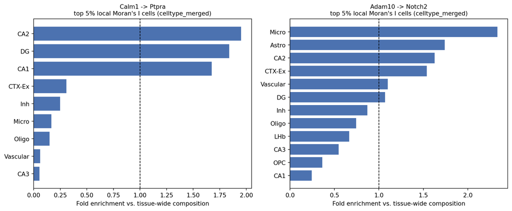

```python
top_frac = 0.05  # top 5% of cells by local Moran's I score
celltype_col = "celltype_merged" if "celltype_merged" in adata.obs.columns else "top_level_cell_type"

fig, axes = plt.subplots(1, len(pair_expr), figsize=(6 * len(pair_expr), 5), squeeze=False)

for i, pe in enumerate(pair_expr):
    row = pe["row"]
    coloc_score = pe["local_score"]

    n_top = max(1, int(top_frac * len(coloc_score)))
    top_idx = top_n_idx(coloc_score, n_top)

    top_counts = adata.obs[celltype_col].iloc[top_idx].value_counts(normalize=True)
    bg_counts  = adata.obs[celltype_col].value_counts(normalize=True)
    enrichment = (top_counts / bg_counts).sort_values(ascending=False).dropna()

    ax = axes[0][i]
    ax.barh(enrichment.index.astype(str), enrichment.values, color="#4c72b0")
    ax.axvline(1, color="black", linestyle="--", linewidth=1)
    ax.set_xlabel("Fold enrichment vs. tissue-wide composition")
    ax.set_title(f"{row['pair_label']}\ntop {top_frac:.0%} local Moran's I cells ({celltype_col})", fontsize=10)
    ax.invert_yaxis()

plt.tight_layout()
plt.show()
```

### 11.1 Baseline expression per cell type

Mean ligand and receptor expression per cell type (all cells). A cell type that barely expresses either gene can’t be enriched above.

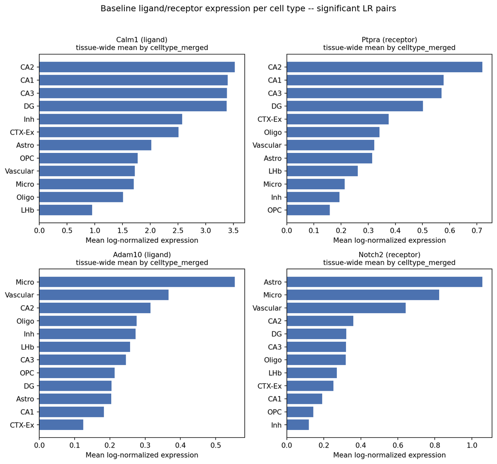

```python
fig, axes = plt.subplots(len(pair_expr), 2, figsize=(10, 4.5 * len(pair_expr)), squeeze=False)

for i, pe in enumerate(pair_expr):
    row = pe["row"]
    by_type = pd.DataFrame({
        celltype_col: adata.obs[celltype_col].values,
        "ligand": pe["ligand"],
        "receptor": pe["receptor"],
    }).groupby(celltype_col, observed=True)[["ligand", "receptor"]].mean()

    for j, gene_role in enumerate(["ligand", "receptor"]):
        ax = axes[i][j]
        ordered = by_type[gene_role].sort_values(ascending=False)
        ax.barh(ordered.index.astype(str), ordered.values, color="#4c72b0")
        ax.set_xlabel("Mean log-normalized expression")
        ax.set_title(f"{row[gene_role]} ({gene_role})\ntissue-wide mean by {celltype_col}", fontsize=10)
        ax.invert_yaxis()

plt.suptitle("Baseline ligand/receptor expression per cell type -- significant LR pairs", y=1.02)
plt.tight_layout()
plt.show()
```

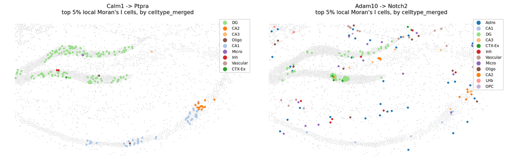

```python
cell_types_all = sorted(adata.obs[celltype_col].dropna().unique().tolist())
cmap_ct = plt.get_cmap("tab20")
color_map = {ct: cmap_ct(i % 20) for i, ct in enumerate(cell_types_all)}

fig, axes = plt.subplots(1, len(pair_expr), figsize=(6.5 * len(pair_expr), 5.5), squeeze=False)

for i, pe in enumerate(pair_expr):
    row = pe["row"]
    coloc_score = pe["local_score"]
    n_top = max(1, int(top_frac * len(coloc_score)))
    top_idx = top_n_idx(coloc_score, n_top)

    ax = axes[0][i]
    ax.scatter(coords_xy[:, 0], coords_xy[:, 1], color="lightgrey", s=2, edgecolors="none")

    top_types = adata.obs[celltype_col].iloc[top_idx]
    for ct in top_types.unique():
        mask = (top_types == ct).values
        ax.scatter(coords_xy[top_idx][mask, 0], coords_xy[top_idx][mask, 1],
                   color=color_map[ct], s=14, label=str(ct), edgecolors="none")

    ax.set_aspect("equal")
    ax.invert_yaxis()
    ax.axis("off")
    ax.set_title(f"{row['pair_label']}\ntop {top_frac:.0%} local Moran's I cells, by {celltype_col}", fontsize=10)
    ax.legend(markerscale=2, fontsize=7, loc="upper right", framealpha=0.8)

plt.tight_layout()
plt.show()
```

## 12 Spatial map of the local Moran’s I score

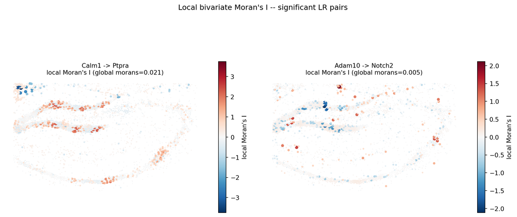

```python
fig, axes = plt.subplots(1, len(pair_expr), figsize=(6 * len(pair_expr), 5.5), squeeze=False)

for i, pe in enumerate(pair_expr):
    row = pe["row"]
    values = pe["local_score"]
    vmax = np.nanmax(np.abs(values)) or 1

    ax = axes[0][i]
    pts = ax.scatter(
        coords_xy[:, 0], coords_xy[:, 1],
        c=values, cmap="RdBu_r", vmin=-vmax, vmax=vmax,
        s=size_from_values(np.abs(values)), edgecolors="none",
    )
    ax.set_title(f"{row['pair_label']}\nlocal Moran's I (global {score_col}={row[score_col]:.3f})", fontsize=10)
    ax.set_aspect("equal")
    ax.invert_yaxis()
    ax.axis("off")
    plt.colorbar(pts, ax=ax, shrink=0.7, label="local Moran's I")

plt.suptitle("Local bivariate Moran's I -- significant LR pairs", y=1.02)
plt.tight_layout()
plt.show()
```

## 13 Manual look at one pair (Igfbpl1 → Dcc)

The same three analyses for a chosen pair, whether or not it passed the filter. Needs the cells above to have been run.

```python
manual_ligand = "Igfbpl1"    # ---- EDIT: change these two to look up a different pair manually ----
manual_receptor = "Dcc"

manual_match = plot_df[(plot_df["ligand"] == manual_ligand) & (plot_df["receptor"] == manual_receptor)]

if manual_match.empty:
    close = plot_df[
        plot_df["ligand"].str.contains(manual_ligand, case=False, na=False)
        | plot_df["receptor"].str.contains(manual_receptor, case=False, na=False)
    ]
    raise RuntimeError(
        f"'{manual_ligand} -> {manual_receptor}' not found in plot_df (exact ligand/receptor match). "
        f"Check spelling/case, or whether it's part of a multi-subunit complex (genes joined by '_'). "
        f"Similar pairs found: {close['pair_label'].tolist() if not close.empty else 'none'}"
    )

manual_pair_id = manual_match.index[0]
manual_row = manual_match.iloc[0]

manual_pe = {
    "pair_id": manual_pair_id,
    "row": manual_row,
    "ligand": complex_expression(manual_row["ligand"]),
    "receptor": complex_expression(manual_row["receptor"]),
    "local_score": to_float_array(bivar_adata[:, manual_pair_id].X),
}

n_nan = int(np.isnan(manual_pe["local_score"]).sum())
n_total = len(manual_pe["local_score"])
print(f"{manual_row['pair_label']}: global {score_col} = {manual_row[score_col]:.4f}"
      + (f", p = {manual_row[pval_col]:.4g}" if pval_col else "")
      + f" | {n_nan}/{n_total} cells ({n_nan/n_total:.1%}) have NaN local score")
```

```
Igfbpl1 -> Dcc: global morans = 0.0017, p = 0.43 | 0/3901 cells (0.0%) have NaN local score
```

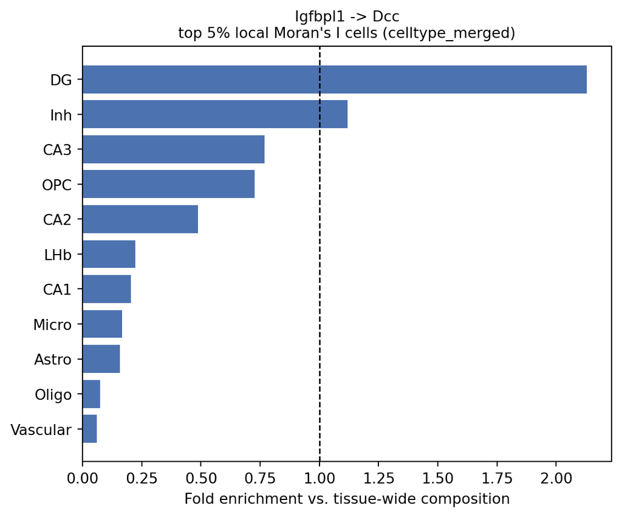

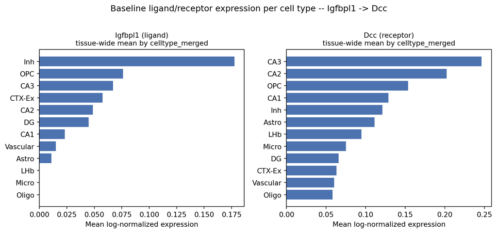

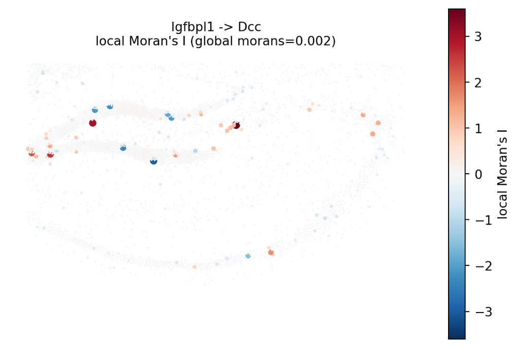

```python
# 1) Which cell types dominate the colocalization -- same fold-enrichment calculation as "Which cell types dominate the colocalization?"
n_top = max(1, int(top_frac * len(manual_pe["local_score"])))
top_idx = top_n_idx(manual_pe["local_score"], n_top)

top_counts = adata.obs[celltype_col].iloc[top_idx].value_counts(normalize=True)
bg_counts = adata.obs[celltype_col].value_counts(normalize=True)
enrichment = (top_counts / bg_counts).sort_values(ascending=False).dropna()

fig, ax = plt.subplots(figsize=(6, 5))
ax.barh(enrichment.index.astype(str), enrichment.values, color="#4c72b0")
ax.axvline(1, color="black", linestyle="--", linewidth=1)
ax.set_xlabel("Fold enrichment vs. tissue-wide composition")
ax.set_title(f"{manual_row['pair_label']}\ntop {top_frac:.0%} local Moran's I cells ({celltype_col})", fontsize=10)
ax.invert_yaxis()
plt.tight_layout()
plt.show()

# 2) Baseline ligand/receptor expression per cell type -- same calculation as "Baseline expression per cell type"
by_type = pd.DataFrame({
    celltype_col: adata.obs[celltype_col].values,
    "ligand": manual_pe["ligand"],
    "receptor": manual_pe["receptor"],
}).groupby(celltype_col, observed=True)[["ligand", "receptor"]].mean()

fig, axes = plt.subplots(1, 2, figsize=(10, 4.5))
for j, gene_role in enumerate(["ligand", "receptor"]):
    ax = axes[j]
    ordered = by_type[gene_role].sort_values(ascending=False)
    ax.barh(ordered.index.astype(str), ordered.values, color="#4c72b0")
    ax.set_xlabel("Mean log-normalized expression")
    ax.set_title(f"{manual_row[gene_role]} ({gene_role})\ntissue-wide mean by {celltype_col}", fontsize=10)
    ax.invert_yaxis()
plt.suptitle(f"Baseline ligand/receptor expression per cell type -- {manual_row['pair_label']}", y=1.02)
plt.tight_layout()
plt.show()

# 3) Spatial map of the local Moran's I score itself -- same calculation as "Spatial map of the local Moran's I score"
values = manual_pe["local_score"]
vmax = np.nanmax(np.abs(values)) or 1

fig, ax = plt.subplots(figsize=(6, 5.5))
pts = ax.scatter(
    coords_xy[:, 0], coords_xy[:, 1],
    c=values, cmap="RdBu_r", vmin=-vmax, vmax=vmax,
    s=size_from_values(np.abs(values)), edgecolors="none",
)
ax.set_title(f"{manual_row['pair_label']}\nlocal Moran's I (global {score_col}={manual_row[score_col]:.3f})", fontsize=10)
ax.set_aspect("equal")
ax.invert_yaxis()
ax.axis("off")
plt.colorbar(pts, ax=ax, shrink=0.7, label="local Moran's I")
plt.tight_layout()
plt.show()
```

### 13.1 Top 5 % cells, coloured by cell type

The raw-score map is dominated by a few extreme cells; this shows where the top-5 % cells (used for the enrichment) actually are.

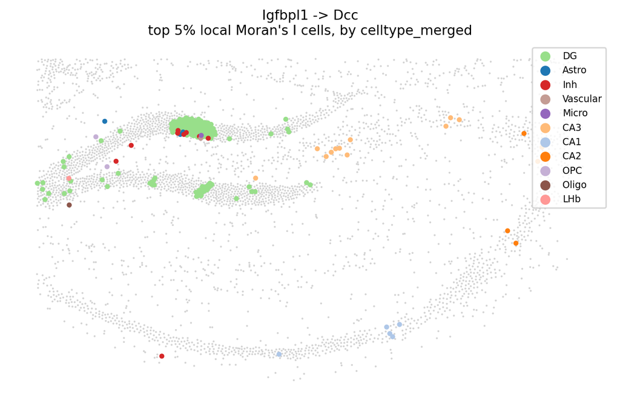

```
DG cells in top 5%: 155 cells, local score range [0.0535, 2.5862]
Tissue-wide local score range (all cells): [-2.9309, 3.6002]
If DG's max here is far below the tissue-wide max, that's the color/size scale saturating on a few non-DG outlier cells, not an absence of DG signal.
```

```python
# top-5 % cells, coloured by cell type
n_top = max(1, int(top_frac * len(manual_pe["local_score"])))
top_idx = top_n_idx(manual_pe["local_score"], n_top)

fig, ax = plt.subplots(figsize=(6.5, 5.5))
ax.scatter(coords_xy[:, 0], coords_xy[:, 1], color="lightgrey", s=2, edgecolors="none")

top_types = adata.obs[celltype_col].iloc[top_idx]
for ct in top_types.unique():
    mask = (top_types == ct).values
    ax.scatter(coords_xy[top_idx][mask, 0], coords_xy[top_idx][mask, 1],
               color=color_map[ct], s=14, label=str(ct), edgecolors="none")

ax.set_aspect("equal")
ax.invert_yaxis()
ax.axis("off")
ax.set_title(f"{manual_row['pair_label']}\ntop {top_frac:.0%} local Moran's I cells, by {celltype_col}", fontsize=10)
ax.legend(markerscale=2, fontsize=7, loc="upper right", framealpha=0.8)
plt.tight_layout()
plt.show()

# DG score range within the top 5 % vs the whole tissue
dg_mask_top = (top_types == "DG").values
if dg_mask_top.any():
    dg_scores_top = manual_pe["local_score"][top_idx][dg_mask_top]
    all_scores = manual_pe["local_score"]
    print(f"DG cells in top {top_frac:.0%}: {dg_mask_top.sum()} cells, "
          f"local score range [{dg_scores_top.min():.4f}, {dg_scores_top.max():.4f}]")
    print(f"Tissue-wide local score range (all cells): "
          f"[{np.nanmin(all_scores):.4f}, {np.nanmax(all_scores):.4f}]")
    print("If DG's max here is far below the tissue-wide max, that's the color/size scale "
          "saturating on a few non-DG outlier cells, not an absence of DG signal.")
else:
    print("No DG cells landed in the top 5% for this run.")
```

## 14 How the local score is built (top pair)

Ligand, receptor, neighbour-averaged receptor, and liana’s local score. The neighbour average is a simplified illustration, not liana’s exact computation.

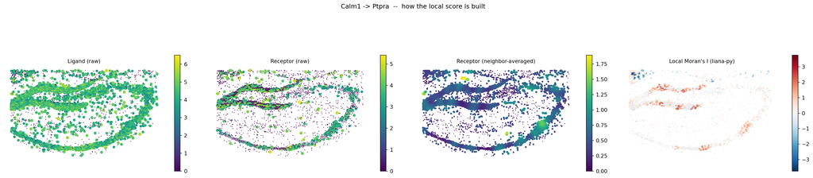

```python
example = pair_expr[0]  # top-ranked pair by global Moran's I
row = example["row"]

W = adata.obsp["spatial_connectivities"]
row_sums = np.asarray(W.sum(axis=1)).flatten()
row_sums[row_sums == 0] = 1  # avoid divide-by-zero for any isolated cell
receptor_lag = np.asarray(W.dot(example["receptor"])).flatten() / row_sums

panels = [
    ("Ligand (raw)", example["ligand"], "viridis", False),
    ("Receptor (raw)", example["receptor"], "viridis", False),
    ("Receptor (neighbor-averaged)", receptor_lag, "viridis", False),
    ("Local Moran's I (liana-py)", example["local_score"], "RdBu_r", True),
]

fig, axes = plt.subplots(1, 4, figsize=(22, 5))
for ax, (title, values, cmap, diverging) in zip(axes, panels):
    if diverging:
        vmax = np.nanmax(np.abs(values)) or 1
        pts = ax.scatter(coords_xy[:, 0], coords_xy[:, 1], c=values, cmap=cmap,
                          vmin=-vmax, vmax=vmax, s=size_from_values(np.abs(values)), edgecolors="none")
    else:
        pts = ax.scatter(coords_xy[:, 0], coords_xy[:, 1], c=values, cmap=cmap,
                          s=size_from_values(values), edgecolors="none")
    ax.set_title(title, fontsize=10)
    ax.set_aspect("equal")
    ax.invert_yaxis()
    ax.axis("off")
    plt.colorbar(pts, ax=ax, shrink=0.7)

plt.suptitle(f"{row['pair_label']}  --  how the local score is built", y=1.05)
plt.tight_layout()
plt.show()
```

## 15 Save results for downstream use

```python
plot_df.to_csv(f"{out_dir}/bivariate_morans_global_summary.csv", index=False)
```

## 16 Notes

- Global Moran’s I says ligand and receptor co-vary somewhere in the tissue, not which cell types drive it.
- liana’s p-value tests against shuffled expression; spatially patterned genes pass easily. See the control-pair test in `10` for comparison with random genes.